# 근 구하기(Roots Finding)

$f(x) = c$ : 이 등식을 만족하는 $x$를 찾는 문제  
$f(x)-c = F(x)$로 바꾼다.

**대표적인 수치해석적 해법** :

- 이분법(Bisection Method)
- 뉴턴-랩슨 방법(Newton-Raphson Method)
- 할선법(Secant method)

## 이분법

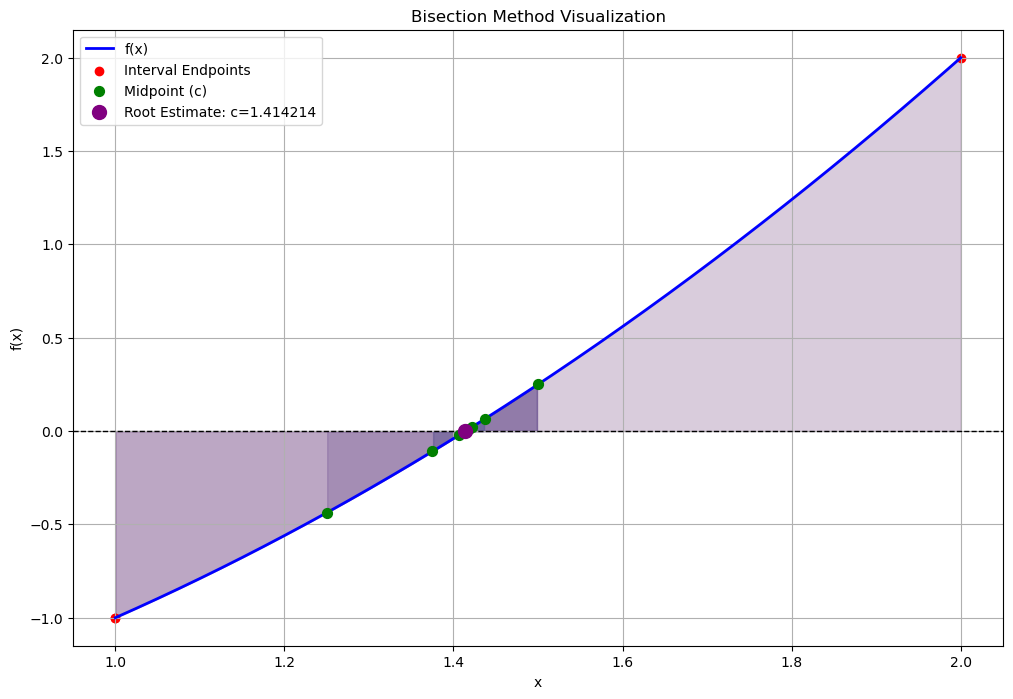

```
1.4142141342163086
```

```python
# Re-run the visualization code without external link issues

import numpy as np
import matplotlib.pyplot as plt
from Root import RootFinder

# 함수 정의 (f(x) = x^2 - 2)
def f(x):
    return x**2 - 2

finder = RootFinder(f=f)

# 이분법 실행 및 시각화
root, history = finder.bisection_visualize(1, 2, tol=1e-6)
finder.plot_bisection(history)

root  # 결과 출력
```

이분법은 함수 $ f(x) $가 **연속**이고, 두 점 $ a $와 $ b $에서 함수의 값 $ f(a) $와 $ f(b) $의 부호가 서로 다를 때, 그 사이에 적어도 하나의 **근**이 존재한다는 중간값 정리를 이용한 수치해석적 방법입니다.

### 1. **이분법의 원리**

이분법의 목표는 함수 $ f(x) = 0 $의 근을 포함하는 구간을 점점 좁혀가며 근을 찾아내는 것입니다.

#### 중간값 정리:

- 함수 $ f(x) $가 구간 $[a, b]$에서 **연속**이고, $ f(a) \cdot f(b) < 0 $이라면, 이 구간 안에 적어도 하나의 근이 존재합니다.

이분법은 구간 $[a, b]$에서 다음 단계를 반복합니다.

### 2. **이분법 알고리즘**

1. 초기 구간 $[a, b]$에서 함수의 값이 $ f(a) \cdot f(b) < 0 $이 되는 $ a $와 $ b $를 선택합니다.
2. 구간의 중간점 $ c $를 계산합니다: $$ c = \frac{a + b}{2} $$
3. 함수값 $ f(c) $를 계산하여, 다음의 경우에 따라 구간을 갱신합니다:
   - $ f(a) \cdot f(c) < 0 $이면 근이 구간 $[a, c]$ 안에 존재하므로 $ b = c $로 설정합니다.
   - $ f(c) \cdot f(b) < 0 $이면 근이 구간 $[c, b]$ 안에 존재하므로 $ a = c $로 설정합니다.
4. 원하는 오차 범위 $\epsilon$에 도달할 때까지 또는 구간 $[a, b]$의 길이가 충분히 작아질 때까지 이 과정을 반복합니다.

### 3. **이분법의 수식**

- 초기 구간: $ [a, b] $
- 중간점: $ c = \frac{a + b}{2} $
- 새로운 구간:
  - 만약 $ f(a) \cdot f(c) < 0 $, 그러면 $ [a, c] $로 구간을 갱신.
  - 만약 $ f(c) \cdot f(b) < 0 $, 그러면 $ [c, b] $로 구간을 갱신.

### 4. **종료 조건**

- $ |b - a| < \epsilon $ (구간의 길이가 충분히 작아질 때)
- $ f(c) = 0 $일 때, $ c $가 근이 됩니다.

### 5. **이분법의 장점과 단점**

- **장점**:
  - 매우 단순하고 구현이 쉽습니다.
  - 항상 수렴하며, 근이 구간 내에 존재한다는 조건이 만족되면 정확한 결과를 제공합니다.
- **단점**:
  - 수렴 속도가 느립니다. 원하는 정확도에 도달하려면 많은 반복이 필요할 수 있습니다.
  - 함수가 복잡하거나 근이 여러 개일 경우에는 모든 근을 찾지 못할 수 있습니다.

### 6. **예시**

만약 함수 $ f(x) = x^2 - 2 $에서 $ \sqrt{2} $를 구하고자 한다면, 구간 $ [1, 2] $에서 이분법을 적용할 수 있습니다. 이분법을 사용하여 근을 점점 좁혀가면 최종적으로 $ \sqrt{2} $를 매우 정확하게 구할 수 있습니다.

### Chapra 책 5.24번 예제

물에 뜬 구체의 물 밖 부분의 부피 V $$ V = \frac{\pi}{3}h^2 (3r-h) $$

반지름: $r=1$  
구의 밀도: $\rho_A=200kg/m^3$  
물의 밀도: $\rho_W=1000kg/m^3$

$$ 0.2 = 1-\frac{h^2}{4} (3-h)\quad (\because\ r=1) $$

$$ F(h)=1-\frac{h^2}{4}(3-h) - 0.2 \left(=\frac{\rho_A}{\rho_W} \right) $$

$$ func(h) \{1 - h^2 / 4 * (3-h) - 0.2\} $$

```
#define func(x) (1.0 - (pow(x, 2) / 4.0) * (3.0-x)- 0.2)
```

C코드 결과

```
a = 0.000000, b = 2.000000
a = 1.000000, b = 2.000000
a = 1.000000, b = 1.500000
a = 1.250000, b = 1.500000
a = 1.375000, b = 1.500000
a = 1.375000, b = 1.437500
a = 1.406250, b = 1.437500
a = 1.421875, b = 1.437500
a = 1.421875, b = 1.429688
a = 1.421875, b = 1.425781
a = 1.423828, b = 1.425781
a = 1.424805, b = 1.425781
a = 1.425293, b = 1.425781
a = 1.425537, b = 1.425781
a = 1.425659, b = 1.425781
a = 1.425659, b = 1.425720
a = 1.425690, b = 1.425720
a = 1.425705, b = 1.425720
a = 1.425713, b = 1.425720
a = 1.425716, b = 1.425720
a = 1.425718, b = 1.425720
a = 1.425718, b = 1.425719
a = 1.425718, b = 1.425719
root x = 1.425719
```

## 뉴턴-랩슨 방법

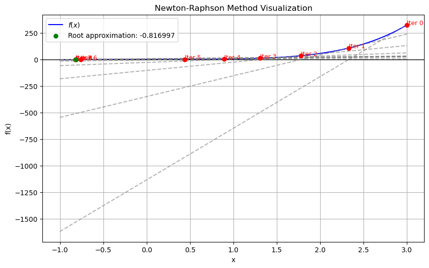

```
-0.8169972073467128
```

```python
from Root import RootFinder

# Define the function and its derivative for a 4th-degree polynomial
def f(x):
    return x**5 + 3*x**3 + 2

def df(x):
    return 5*x**4 + 9*x**2

finder = RootFinder(f=f, df=df)

# Initial guess and Newton-Raphson execution
x0 = 3.0  # Initial guess
root, history = finder.newton_raphson(x0)
finder.plot_newton_raphson(history, start=-1, end=3)

root  # Return the root
```

접선의 방정식 $F(x) = f(x_0) + (x-x_0) f'(x_0) = 0$으로부터 시작한다.

- 1차 미분을 할 수 있는 함수면 사용이 용이하다.

$$ f(x_0) + (x-x_0)f'(x_0) \\ x = x_0 - \frac{f(x_0)}{f'(x_0)}\\ x - x_0 = \delta = - \frac{f(x_0)}{f'(x_0)} $$

$\delta$가 임의로 정한 수 $\epsilon$보다 작으면 반복을 중단하고 그 시점의 $x_n$을 근으로 판정한다.

### 수업시간 예제

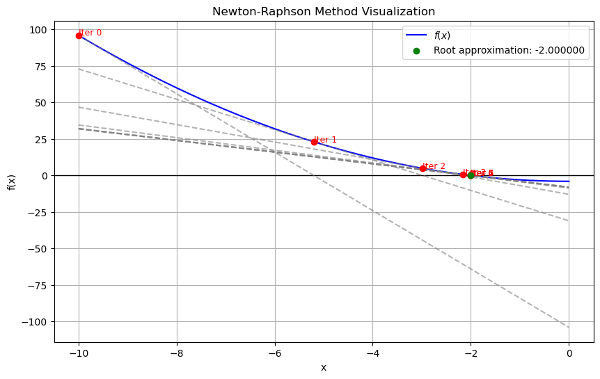

```python
def f(x):
    return x**2 -4

def df(x):
    return 2*x

finder = RootFinder(f=f, df=df)

root, history = finder.newton_raphson(x0=-10, tol=1e-100, max_iter=10000)
finder.plot_newton_raphson(history=history, start=-10, end=0)
```

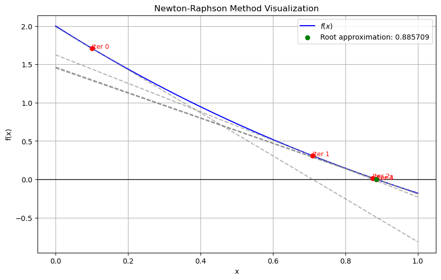

```python
def f(x):
    return np.exp(- x/2) * (4-x) - 2

def df(x):
    return -0.5 * np.exp(-0.5 * x) * (4.0 - x) - np.exp(-0.5 * x)

finder = RootFinder(f=f, df=df)
root, history = finder.newton_raphson(x0=0.1, tol=1e-5, max_iter=1000)
finder.plot_newton_raphson(history=history, start=0, end=1)
```

C코드 정답

```
#define func(x) (exp(-x/2.0)*(4.0-x)-2.0)
#define func_diff(x) (-0.5*exp(-0.5*x)*(4.0-x)-exp(-0.5*x))

/* solution: x=0.885709  */
```

```
x = 0.709308, del = 0.609308
x = 0.875380, del = 0.166072
x = 0.885672, del = 0.010292
x = 0.885709, del = 0.000037
x = 0.885709, del = 0.000000
root x = 0.885709
```

**Chapra PROBLEMS 5.1**

떨어지는 사람의 속도가 46m/s가 되는 drag coefficient 구하기 $$ F(C_d) = \left(\sqrt{g\cdot m / C_d} \tanh{(\sqrt(g \cdot C_d / m) \cdot 9)} -46 \right) $$

$$ \sqrt{gm} \equiv c\\ \sqrt{g/m} \cdot t \equiv d $$

$$ F'(C_d) = \left(c(1/C_d)^{(1/2)} \cdot \tanh(dC_d^{1/2}) \right)\\ = -(1/2) C \cdot C_d^{-3/2} \tanh(d \cdot C_d^{1/2}) + C \cdot C_d^{-1/2}\\ (1-\tanh^2(d \cdot C_d^{1/2}))\cdot d \cdot 1/2 \cdot C_d^{-1/2} $$

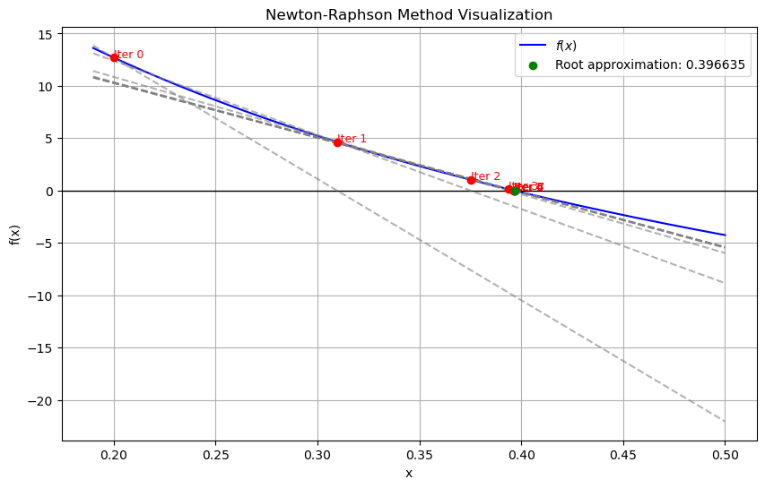

```python
def f(x):
    return np.sqrt(95.0 * 9.81 /x) * np.tanh(np.sqrt(9.81 * x / 95.0) * 9) - 46

def df(x):
    c = np.sqrt(9.81 * 95)
    d = np.sqrt(9.81 / 95) * 9
    return -(1/2) * c * x**(-3/2) * np.tanh(d * x**(1/2)) + c * x**(-1/2) *\
    (1- np.tanh(d * x**(1/2))) * d * 1/2 * x**(-1/2)

finder = RootFinder(f=f, df=df)
root, history = finder.newton_raphson(x0=0.2)
finder.plot_newton_raphson(history=history, start=0.19, end=0.5)
```

```
#define c (sqrt(9.81 * 95.0))
#define d (sqrt(9.81 / 95.0) * 9.0)
#define func(x) (sqrt(95.0 * 9.81 /x) * tanh(sqrt(9.81 * x / 95.0)\
	 * 9.0) - 46)
#define func_diff(x) (-(1.0/2.0) * c * pow(x, -3.0/2.0) \
* tanh(d * pow(x,(1.0/2.0)))\
+ c * pow(x, (-1.0/2.0)) *\
(1.0- tanh(d * pow(x, (1.0/2.0)))) * d * 1.0/2.0 * \
pow(x, (-1.0/2.0)))
```

```
x = 0.204968, del = 0.104968
x = 0.313652, del = 0.108683
x = 0.376735, del = 0.063083
x = 0.393946, del = 0.017211
x = 0.396346, del = 0.002401
x = 0.396605, del = 0.000259
x = 0.396632, del = 0.000027
x = 0.396635, del = 0.000003
x = 0.396635, del = 0.000000
root x = 0.396635
```

**Chapra PROBLEM 5.24** 부력이 있는 구체

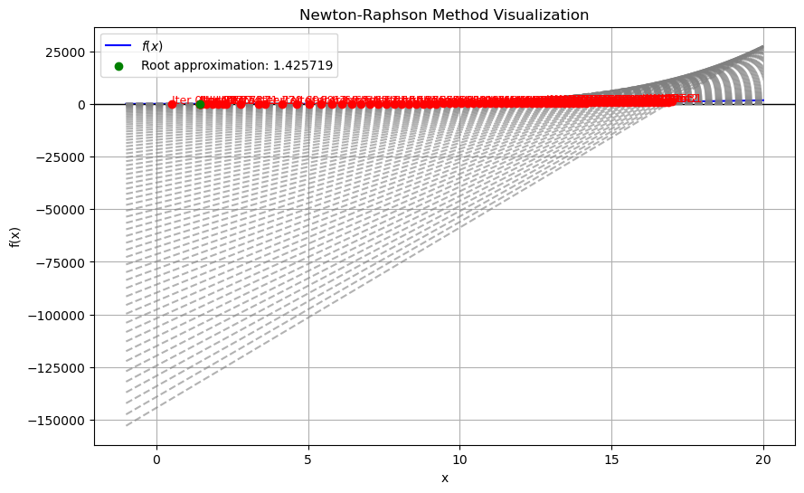

```python
def f(x):
    return (1.0 - 0.25 * np.power(x,2.0) * (3.0-x) - (0.2))

def df(x):
    return (-2.0 * x * 0.25 * (3.0 - x) * -0.25 * np.power(x,2.0) * -1)

finder = RootFinder(f=f, df=df)
root, history = finder.newton_raphson(x0=0.5)
finder.plot_newton_raphson(history=history, start=-1, end=20)
```

C코드 정답

```
root x = 1.425719
```

# 할선법

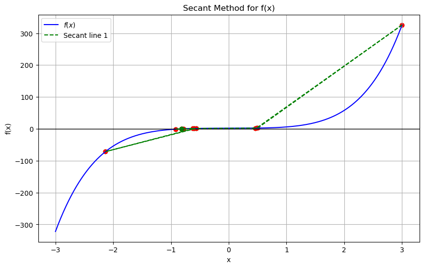

```
-0.8169972066977633
```

```python
import numpy as np
import matplotlib.pyplot as plt
from Root import RootFinder

# 함수 정의
def f(x):
    return x**5 + 3*x**3 + 2

# 초기값 설정
x0 = 0.5  # 첫 번째 추정
x1 = 3.0  # 두 번째 추정

finder = RootFinder(f=f)

# 할선법 실행
root, history = finder.secant_method(x0, x1)

# 할선법 과정 시각화
finder.plot_secant_method(history)

root  # 근을 출력
```

$$ f'(x_i) \approx \frac{f(x_{i-1})-f(x_i)}{\delta_i}\\ \delta_i = x_{i-1} - x_i \\ x_{i+1} = x_i - \frac{\delta_i f(x_i)}{f(x_i + \delta_i)-f(x_i)} $$

해석적인 미분 대신 실제 함수값으로 미분계수를 구해 $x$값을 변화시킨다.

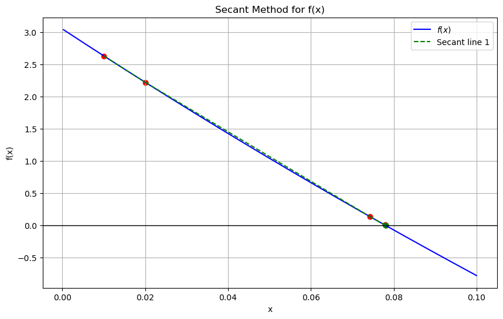

```
Root: 0.07808042809083096
```

```python
def f(x):
    return (np.sqrt(95.0 * 9.81 /x) * np.tanh(np.sqrt(9.81 * x / 95.0)*5.0)-46.0)

finder = RootFinder(f=f)
root, history = finder.secant_method(x0=0.01, x1=0.02)
finder.plot_secant_method(history=history, start=0, end=0.1)
print(f"Root: {root}")
```

# Inverse Interolation Method

```python
import numpy as np
x = np.linspace(1.05, 1.2, 4, endpoint=True)
f_x = np.array([-0.35, -0.23, -0.065, 0.172])
x, f_x
```

```
(array([1.05, 1.1 , 1.15, 1.2 ]), array([-0.35 , -0.23 , -0.065,  0.172]))
```

보간법으로 함수값이 0일 때의 x값을 보간해낸다. 그러면 함수값이 0이므로 근을 찾은 게 된다.

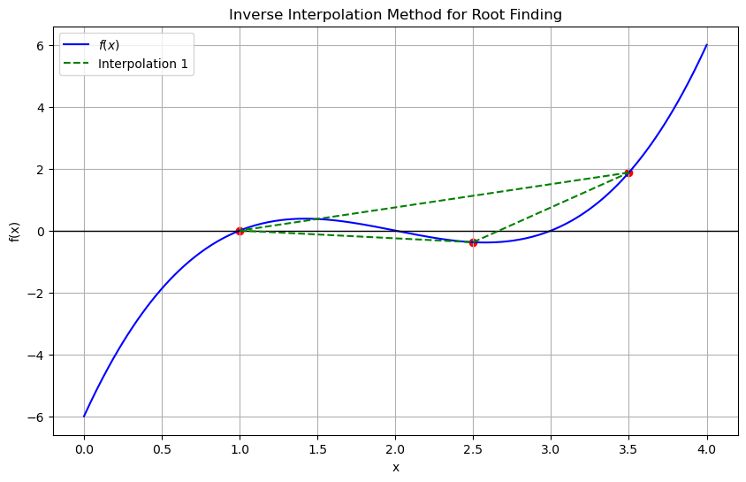

```
1.0
```

```python
import numpy as np
import matplotlib.pyplot as plt
from Root import RootFinder

# 함수 정의 (f(x) = x^3 - 6x^2 + 11x - 6)
def f(x):
    return x**3 - 6*x**2 + 11*x - 6

# 초기값 설정
x0, x1, x2 = 1.0, 2.5, 3.5  # 초기 추정값들

finder = RootFinder(f=f)
# 역 보간법 실행
root, history = finder.inverse_interpolation(x0, x1, x2)

# 역 보간법 과정 시각화
finder.plot_inverse_interpolation(history)

root  # 근을 출력
```

# 예제

## Chapra 책 PROBLEM 6.33 (195p)

$$ c = 77e^{-1.5t} + 20e^{-0.08t} $$

t=0 일 때 c=97  
c=15가 되는 t=?

$$ t_0 = 6 \\ \epsilon = 0.01 $$

### 뉴턴-랩슨 방법

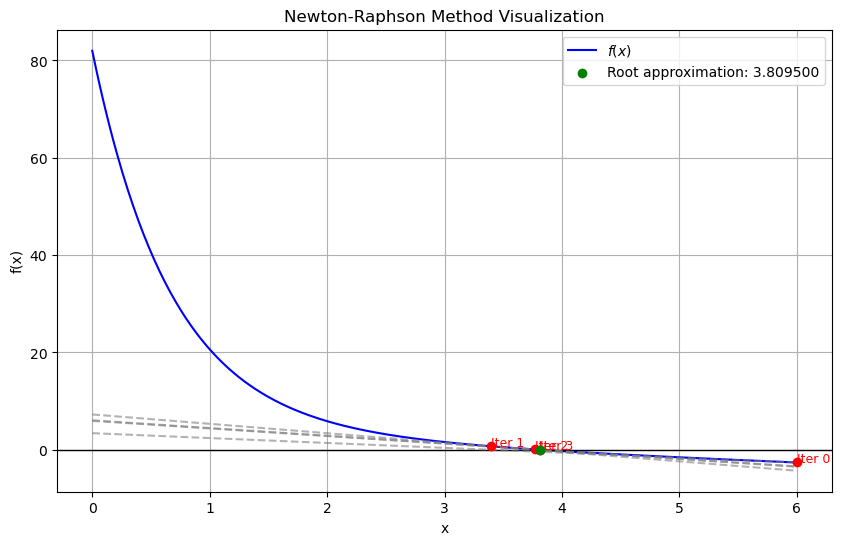

```python
def f(t):
    return 77 * np.exp(-1.5 * t) + 20 * np.exp(-0.08 * t) - 15

def df(t):
    return -115.5 * np.exp(-1.5 * t) - 1.6 * np.exp(-0.08 * t)

finder = RootFinder(f=f, df=df)

root, history = finder.newton_raphson(x0=6, tol=0.01, max_iter=100)
finder.plot_newton_raphson(history=history, start=0, end=6)
```

### 할선법

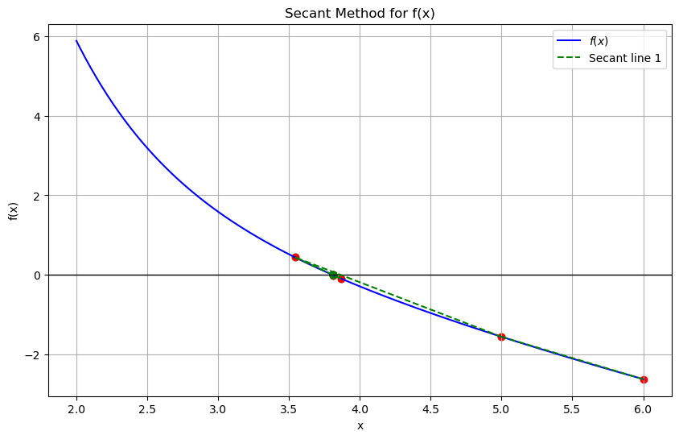

```
Root: 3.8095000761895044
```

```python
finder = RootFinder(f=f)

root, history = finder.secant_method(x0=6, x1=5, tol=1e-100)
finder.plot_secant_method(history=history, start=2, end=6
                          )
print(f'Root: {root}')
```

### 이분법

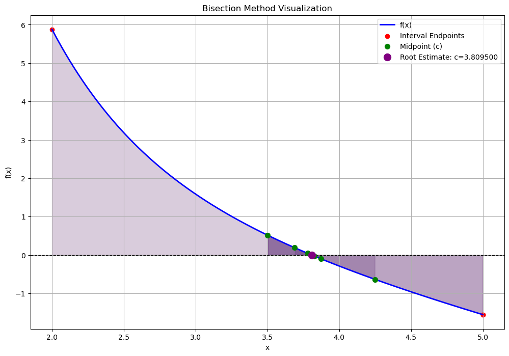

```
Root: 3.8095000761895044
```

```python
finder = RootFinder(f=f)

root, history = finder.bisection_visualize(a=2, b=5, tol=1e-100)
finder.plot_bisection(history=history, start=2, end=5)
print(f'Root: {root}')
```

## 교재 p.77 예제 II-2-4

### Interpolation 방법

$$ f(x) = e^{-x/2} (4-x) -2 $$

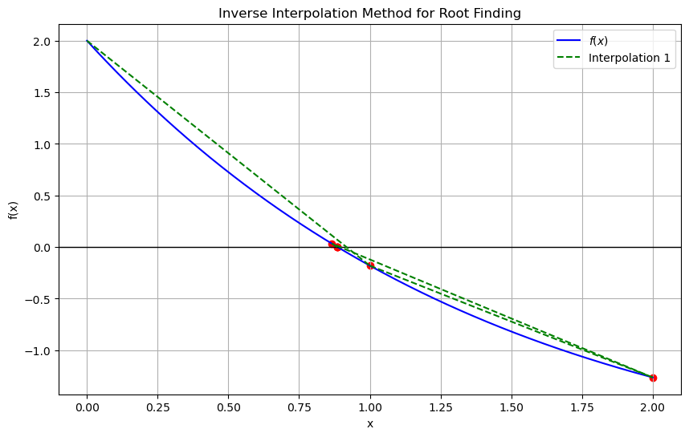

```
Root: 0.885708802009157
```

```python
def f(x):
    return np.exp(-x / 2) * (4-x) - 2

finder = RootFinder(f=f)

root, history = finder.inverse_interpolation(x0=0, x1=1, x2=2)
finder.plot_inverse_interpolation(history=history, start=0, end=2)
print(f'Root: {root}')
```

## Chapra 책 PROBELM 6-21 (193p)

공을 던져서 그려지는 포물선이 1m 높이에서 포수에게 닿을 투척 각도

$$ y=(\tan(\theta _0))x - g/(2v^2_0 \cos^2(\theta _0)) x^2 + y_0 $$

$$ v_0 \equiv 30\text{m/s} \\ x \equiv 90\text{m}\\ y_0 \equiv 1.8\text{m} $$

$$ 1=(\tan(\theta _0)) \times 90 - 9.81/(2\times 30^2 \cos^2 (\theta_0)) \times 90^2 + 1.8 $$

$$ f(\theta _0) = \tan\left(\pi /180 \times \theta _0 \right) \times 90 - 9.81 / (2 \times 30^2 \cos^2 \left(\pi /180 \times \theta _0 \right)) \times x^2 + 1.8 $$

$$ \theta_0 = 37.9589... \\ \theta_1 = 51.5314746 $$

```python
def f(x):
    return np.tan(np.pi / 180 * x) * 90 - 9.81 /(2 * 30**2 * np.cos(np.pi /180 * x) ** 2) * 90**2 + 1.8

f(37.9589), f(51.5314746)
```

```
(0.9999514478609683, 1.0002487415573313)
```

```python
def f(x):
    res = np.tan(np.pi / 180 * x) * 90 - 9.81 /(2 * 30**2 * np.cos(np.pi /180 * x) ** 2) * 90**2 + 1.8 - 1
    return res
```

### 할선법

[figure not shown]

[output not shown]

```python
finder = RootFinder(f=f)

root, history = finder.secant_method(x0=0.01, x1=0.02)
finder.plot_secant_method(history=history, start=0, end=2)
print(f"Root: {root}")
```

### 이분법

[figure not shown]

[output not shown]

```python
root, history = finder.bisection_visualize(a=0, b=2)
finder.plot_bisection(history=history, start=0, end=2)
print(f'Root: {root}')
```

```
x = 26.964591, del = 26.944591
x = 33.230613, del = 6.266021
x = 35.812493, del = 2.581880
x = 36.329705, del = 0.517212
x = 36.379134, del = 0.049429
x = 36.380090, del = 0.000956
x = 36.380092, del = 0.000002
x = 36.380092, del = 0.000000
root x = 36.380092
```

**C코드 정답2**

```
a = 50.000000, b = 60.000000
a = 50.000000, b = 55.000000
a = 50.000000, b = 52.500000
a = 51.250000, b = 52.500000
a = 51.250000, b = 51.875000
a = 51.250000, b = 51.562500
a = 51.406250, b = 51.562500
a = 51.484375, b = 51.562500
a = 51.523438, b = 51.562500
a = 51.523438, b = 51.542969
a = 51.523438, b = 51.533203
a = 51.528320, b = 51.533203
a = 51.530762, b = 51.533203
a = 51.530762, b = 51.531982
a = 51.531372, b = 51.531982
a = 51.531677, b = 51.531982
a = 51.531677, b = 51.531830
a = 51.531677, b = 51.531754
a = 51.531715, b = 51.531754
a = 51.531734, b = 51.531754
a = 51.531744, b = 51.531754
a = 51.531744, b = 51.531749
a = 51.531746, b = 51.531749
a = 51.531746, b = 51.531748
a = 51.531746, b = 51.531747
a = 51.531746, b = 51.531747
a = 51.531746, b = 51.531747
a = 51.531746, b = 51.531746
a = 51.531746, b = 51.531746
root x = 51.531746
```